# Mortgage Delinquency Rates

Jake Vick

4/20/2020

# Executive Summary

Serious delinquency rate is defined as 90 days or more past due, including loans in foreclosure. Without the ability to forecast Serious Delinquency Rate banks are left exposed to increased risk and significant revenue losses. With recent changes in the global economy, it could be beneficial to forecast the serious delinquency rate. Based on the models tested and documented with in this report, Median Quantile Regression proved to be the be the best fit model with an 87.07% accuracy rate when forecasting 4 quarters ahead.

# 1: Serious Delinquency Rate

## 1.1: Overview

A loan is considered “delinquent” when a borrower does not make a loan payment on time. Most lenders allow consumers a grace period for missed payments to get their loan out of delinquency. Once a loan is delinquent for a certain period, it becomes at risk of going into default. The serious delinquency rate is defined as 90 days or more past due, including loans in foreclosure.

Parametric and Non-Parametric Models will be used to forecast delinquency rates. Parametic algorithms have a fixed number of parameters, computationally faster, but make stronger assumptions about the data. In contrast, a non-parametric algorithm uses a flexible number of parameters and makes fewer assumptions about the data.

Initially, exploratory data analysis is conducted to determine the structure of the data. Then, different models are constructed to fit the data and determine what variables are significant to the model. With recent changes in the global economy, this model will determine if the unemployment rate will be a good predictor of mortgage delinquency rates.

## 1.2: Data

All of the data used in this analysis was reported on a quarterly frequency. All data except unemployment has not been seasonally adjusted.

Each variable listed below should have a direct impact on delinquency rates. For example, if the unemployment rate is rising and property values are dropping, it is expected to see an increase in the delinquency rate. This is due in part to people not being able to pay back loans or they just walk away from a loan because of a declining house price.

**Formula:**

Delinquency ~ Unemployment + Personal Income + GDP + Home ownership + Property values

This formula shows that the delinquency rate is the response variable and the other five vectors are predictor variables.

**Delinquency Rates (Response Variable)**

Federal Housing Administration (FHA), U.S. Department of Veterans Affairs (VA), Conventional Loans, and All Loans as a percent of total loans are all included in the serious delinquency rate variables. This data is from the Mortgage Banker Association (MBA): National Delinquency Survey.

**Unemployment Rate (Predictor)**

Total unemployment rate (SA) was pulled from U.S. Bureau of Labor Statistics (BLS): Current Population Survey (CPS).

**Personal Income (Predictor)**

Total personal income (Mil. USD) was pulled from the U.S. Bureau of Economic Analysis (BEA): Quarterly Personal Income - Table 05 [NAICS].

**GDP (Predictor)**

Gross Domestic Product: All industry (Mil. USD) was pulled from the U.S. Bureau of Economic Analysis (BEA): Quarterly Gross Domestic Product by State [NAICS].

**Home ownership (Predictor)**

Home ownership rate was pulled from U.S. Census Bureau (BOC).

**Property values (Predictor)**

FHFA House Price Index of Single-family properties (All Transactions) was pulled from the U.S. Federal Housing Finance Agency (FHFA): House Price Index Datasets.

# 2: USA

## 2.1: Exploratory Data Analysis

Historical US **delinquency rates** for different loan types are analyzed over the last 15 years.

Figure 1 shows all variables graphed in a series of boxplots. This will show a five-number summary of the data and visually identify any outliers in the data set. The outliers must be removed in order to make a better fitting model.

In the first series of charts notice, there are no outliers in the data.

Figure 2 details the historical delinquency rates for different loan types over time. All of the different loan types are near 15-year lows.

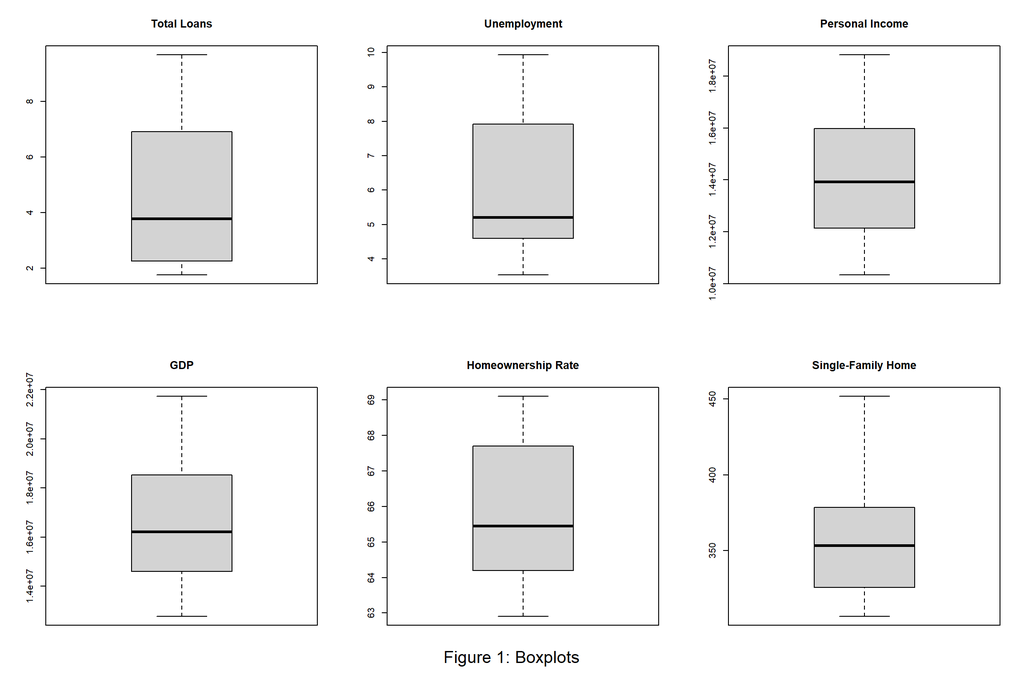

```r
#reading in US Data
USA_Data <- read.csv("DelinquencyData.csv")
n <- length(USA_Data[,1])

#selecting only numerical data
USA <- data.frame(sapply(USA_Data[c(5:n),c(2:10)], function(x) as.numeric(as.character(x))))

#selecting only dates
Dates <- as.Date(USA_Data[c(5:n),1], format = "%m/%d/%Y")

par(mfrow=c(2,3))
boxplot(USA$XMBASDR.IUSA, main="Total Loans")
boxplot(USA$LBR.IUSA, main="Unemployment")
boxplot(USA$YPQ.IUSA, main="Personal Income")
boxplot(USA$GDPQ.IUSA, main="GDP")
boxplot(USA$XHOWNRQ.IUSA, main="Homeownership Rate")
boxplot(USA$XHOFHOPIQ.IUSA, main="Single-Family Home")
mtext("Figure 1: Boxplots", side = 3, line = -59, outer = TRUE, cex=1.2)
```

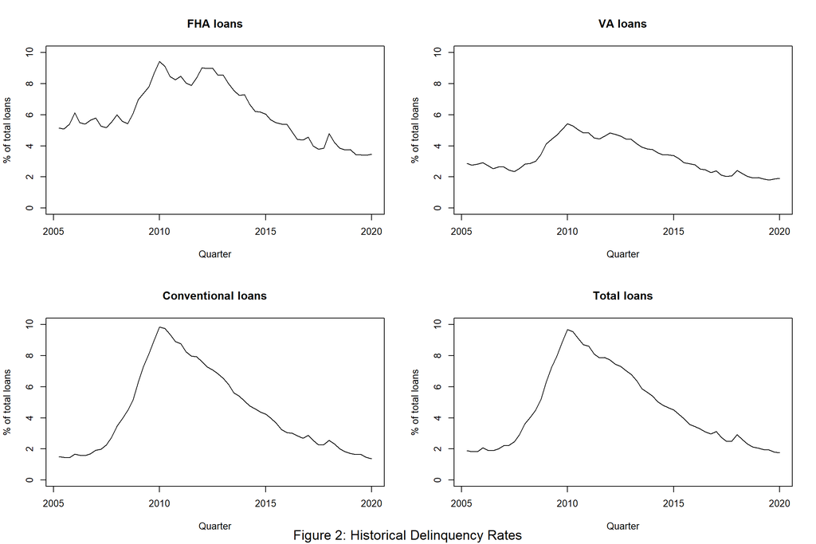

```r
#plot of different loan types
par(mfrow = c(2, 2))
plot(Dates, USA$XMBASDRF.IUSA, type="l",main = "FHA loans", ylab = "% of total loans", xlab = "Quarter", ylim=c(0,10))

plot(Dates, USA$XMBASDRV.IUSA ,type="l",main = "VA loans", ylab = "% of total loans", xlab = "Quarter", ylim=c(0,10))

plot(Dates, USA$XMBASDRC.IUSA,type="l",main = "Conventional loans" , ylab = "% of total loans", xlab = "Quarter", ylim=c(0,10))

plot(Dates, USA$XMBASDR.IUSA,type="l",main = "Total loans", ylab = "% of total loans", xlab = "Quarter", ylim=c(0,10))

mtext("Figure 2: Historical Delinquency Rates", side = 3, line = -48, outer = TRUE, cex =1.2)
```

```r
par(mfrow = c(1, 1))
```

### 2.1.1: Correlation

The data set contains the Delinquency rates, Unemployment Rate, Total Personal Income, Gross Domestic Product, Homeownership Rate, and the price index for Single-Family Home. This section will test the correlation between each variable to see if there are any trends in the data. The closer to one the more correlated the values are.

**Unemployment Rate** is highly correlated with all the Delinquency rates. **Total Personal Income** and **GDP** are both highly correlated. They are both negatively correlated with Delinquency rates since when the economy is doing well more people can pay their loans on time. **Homeownership Rate** has a slight correlation with FHA loans, VA loans, Conventional loans, and Total (in order of correlation). **Price Index: Single-Family Home** has a strong negative correlation with the different loan types.

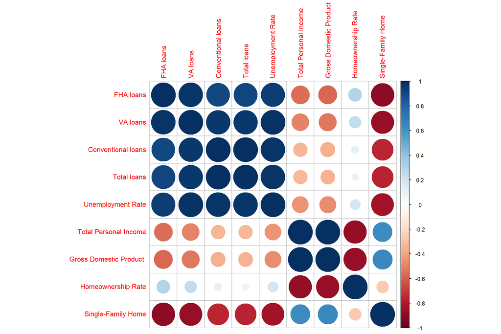

```r
#Correlation for USA
USA_cor <- cor(USA)

#define Headers
Headers <- c("FHA loans", "VA loans", "Conventional loans", "Total loans", "Unemployment Rate", "Total Personal Income", "Gross Domestic Product ", "Homeownership Rate", "Single-Family Home")

#apply headers
row.names(USA_cor) <- Headers
colnames(USA_cor) <- Headers

#corrplot
corrplot(USA_cor)
```

### 2.1.2: Percent Change

Percent change of each variable was calculated to see if it could produce a better-fitted model. Also, lag for the predictors was tested but it showed less correlation than our other results.

The correlation matrix shows slightly less correlation between the variables. This correlation matrix provides visual context to how the variables relationships change over time.

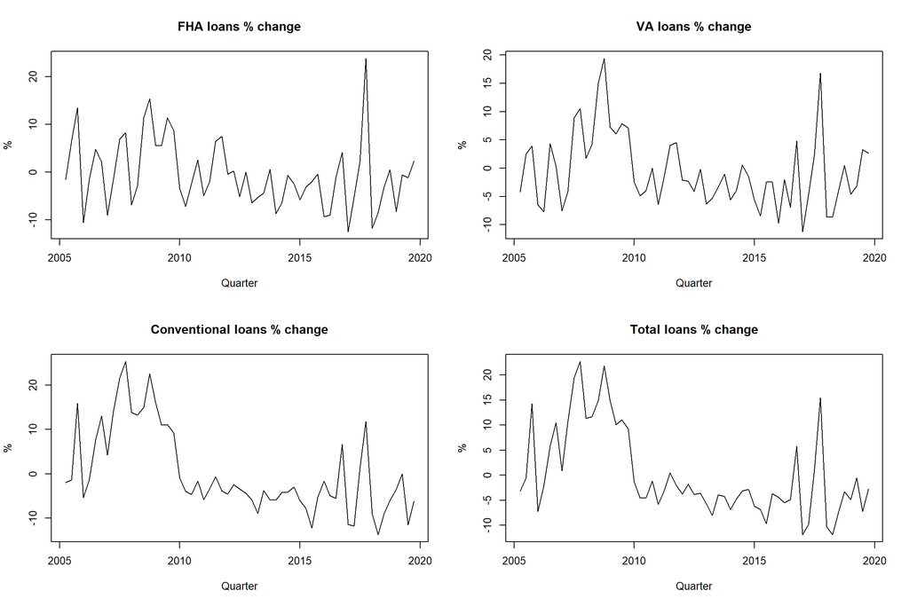

```r
USA_pc_Data <- read.csv("USpc.csv")
n <- length(USA_pc_Data[,1])
USA_pc <- data.frame(sapply(USA_pc_Data[c(5:n),c(2:10)], function(x) as.numeric(as.character(x))))
Dates_pc <- as.Date(USA_Data[c(5:n),1], format = "%m/%d/%Y")

#plot of different loan types
par(mfrow = c(2, 2))
plot(Dates_pc, USA_pc$XMBASDRF.IUSA, type="l",main = "FHA loans % change", ylab = "%", xlab = "Quarter")

plot(Dates_pc, USA_pc$XMBASDRV.IUSA, type="l",main = "VA loans % change", ylab = "%", xlab = "Quarter")

plot(Dates_pc, USA_pc$XMBASDRC.IUSA, type="l",main = "Conventional loans % change" , ylab = "%", xlab = "Quarter")

plot(Dates_pc, USA_pc$XMBASDR.IUSA, type="l",main = "Total loans % change", ylab = "%", xlab = "Quarter")
```

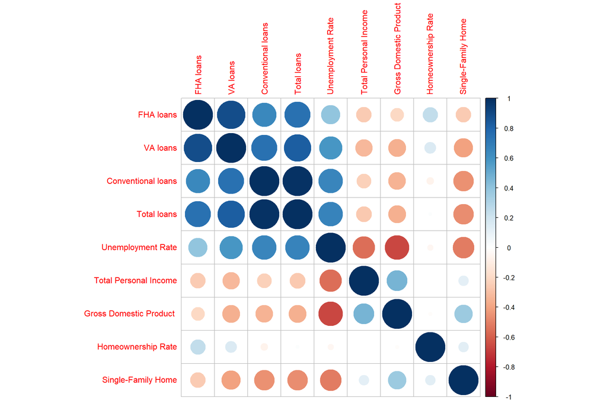

```r
par(mfrow = c(1, 1))

#correlation
USA_pc_cor <- cor(USA_pc)
row.names(USA_pc_cor) <- Headers
colnames(USA_pc_cor) <- Headers

#corrplot
corrplot(USA_pc_cor)
```

# 3: Parametric Model

**Benefits of Parametric Machine learning Algorithms:**

- Fitting the data to a linear line is easier to understand and interpret results
- Speed
- Don’t require as much training data

**Limitations of Parametric Machine learning Algorithms:**

- Constrained by trying to fit just a linear model
- Limited complexity

## 3.1: Linear Regression

**Multiple Linear Regressions (MLR)** were used to forecast the delinquency rate. The MLR model uses several explanatory (predictor) variables to predict the outcome of a response variable. As the name suggests, the goal is to model a linear relationship between the predictor variables and the response variable.

### 3.1.1 Linear Model (ALL)

This model has the respones variable set to Delinquency Rate for all loans while Unemployment, personal income, GDP, Homeownership rate, and home prices are the predictors.

**Interpreting Outputs**

Residuals:

- The difference between the actual response value and the one the model predicted is called residuals. The output below is shown as a five-number summary of the residuals. When assessing how well the model fits the data, a symmetrical distribution across the points with a mean value of 0 is very important. The first model, fit_USA, fits the symmetrical distribution rather well.

Coefficients:

- Coefficients represent the intercept and slope terms in the linear model. The estimate returns the intercept and the slope for that variable. Standard Error is the average that the coefficient estimate varies from the actual response variable T-value is a measure of how many standard deviations our coefficient estimate is away from 0. A large T-values show there is a relationship between the response and predictor. P-value of 5% or less indicates that the value is significant.

Residual Standard Error:

- The average amount that the response variable will deviate from the true regression line is the standard error.

Multiple R-Squared, Adj. R-Squared:

- R-Squared provides a measure of how well the model is fitted to the actual data. A measure of the linear relationship between the predictors and response variable. It is always between 0 and 1, closer to 1 the better the model.

F-Statistic:

- The F-statistic is a good indicator of whether there is a relationship between the predictor and response variable. The further from 1 the better.

```r
#Linear Model test 1 ----
fit_USA <- lm(XMBASDR.IUSA ~ LBR.IUSA + YPQ.IUSA + GDPQ.IUSA + XHOWNRQ.IUSA + XHOFHOPIQ.IUSA, data = USA)
summary(fit_USA)
```

```
##
## Call:
## lm(formula = XMBASDR.IUSA ~ LBR.IUSA + YPQ.IUSA + GDPQ.IUSA +
##     XHOWNRQ.IUSA + XHOFHOPIQ.IUSA, data = USA)
##
## Residuals:
##      Min       1Q   Median       3Q      Max
## -0.84201 -0.28030 -0.00568  0.18710  1.06082
##
## Coefficients:
##                  Estimate Std. Error t value Pr(>|t|)
## (Intercept)    -2.262e+00  8.058e+00  -0.281  0.77997
## LBR.IUSA        1.358e+00  5.920e-02  22.946  < 2e-16 ***
## YPQ.IUSA        1.398e-06  5.057e-07   2.765  0.00778 **
## GDPQ.IUSA      -1.281e-06  5.017e-07  -2.553  0.01355 *
## XHOWNRQ.IUSA   -4.547e-02  1.185e-01  -0.384  0.70271
## XHOFHOPIQ.IUSA  8.529e-03  5.414e-03   1.575  0.12099
## ---
## Signif. codes:  0 '***' 0.001 '**' 0.01 '*' 0.05 '.' 0.1 ' ' 1
##
## Residual standard error: 0.4372 on 54 degrees of freedom
## Multiple R-squared:  0.9719, Adjusted R-squared:  0.9693
## F-statistic:   374 on 5 and 54 DF,  p-value: < 2.2e-16
```

**Model Summary**

The first model fits the data surprisingly well. The significant predictors were unemployment, personal income, and GDP. The model produced residuals that are normally distributed around 0, low standard error, and a close to 1 Adjusted R-Squared.

**Testing Model**

The code shown below breaks the original data up into training and testing data sets. This will enable testing of the model’s accuracy by predicting values and comparing them to the actual data. The Mean Squared Error (MSE) which, is the average of all of the squared differences between the true values and the predicted values will be used to test against the other models. When considering model accuracy, the lower MSE value, the greater the model’s accuracy.

```r
#train & test
n <- length(USA[,1])
obs <- n*.8
USA.train <- USA[c(1:obs), ]
USA.test <- USA[obs:n, ]

#acurracy
fit_USA <- lm(XMBASDR.IUSA ~ LBR.IUSA + YPQ.IUSA + GDPQ.IUSA + XHOWNRQ.IUSA + XHOFHOPIQ.IUSA, data = USA.train)
pred_USA <- predict(fit_USA, USA.test)
mean((pred_USA - USA.test$XMBASDR.IUSA)^2)
```

```
## [1] 5.207131
```

### 3.1.2 Linear Model (% change)

The second model, which uses the percent change of all variables, resulted in a less than satisfactory fit on the data. Out of 1, the adjusted R-Squared resulted in a 0.43, therefore, the model did not accurately predict the data.

```r
#Percent Change test
fit_USA_pc <- lm(XMBASDR.IUSA ~ LBR.IUSA + YPQ.IUSA + GDPQ.IUSA + XHOWNRQ.IUSA + XHOFHOPIQ.IUSA, data = USA_pc)
summary(fit_USA_pc)
```

```
##
## Call:
## lm(formula = XMBASDR.IUSA ~ LBR.IUSA + YPQ.IUSA + GDPQ.IUSA +
##     XHOWNRQ.IUSA + XHOFHOPIQ.IUSA, data = USA_pc)
##
## Residuals:
##    Min     1Q Median     3Q    Max
## -9.609 -3.712 -1.856  2.436 17.799
##
## Coefficients:
##                Estimate Std. Error t value Pr(>|t|)
## (Intercept)     -0.9070     1.9067  -0.476    0.636
## LBR.IUSA         1.2437     0.2709   4.591 2.75e-05 ***
## YPQ.IUSA         0.6597     0.9945   0.663    0.510
## GDPQ.IUSA        2.0092     1.7698   1.135    0.261
## XHOWNRQ.IUSA     1.2553     1.8407   0.682    0.498
## XHOFHOPIQ.IUSA  -0.9978     0.7233  -1.380    0.173
## ---
## Signif. codes:  0 '***' 0.001 '**' 0.01 '*' 0.05 '.' 0.1 ' ' 1
##
## Residual standard error: 6.583 on 53 degrees of freedom
## Multiple R-squared:  0.4826, Adjusted R-squared:  0.4337
## F-statistic: 9.885 on 5 and 53 DF,  p-value: 1.021e-06
```

```r
n <- length(USA_pc[,1])
obs <- n*.8
USA.train.pc <- USA_pc[c(1:obs), ]
USA.test.pc <- USA_pc[obs:n, ]
fit_USA_pc <- lm(XMBASDR.IUSA ~ LBR.IUSA + YPQ.IUSA + GDPQ.IUSA + XHOWNRQ.IUSA + XHOFHOPIQ.IUSA, data = USA.train.pc)
pred_USA_pc <- predict(fit_USA_pc, USA.test.pc)
mean((pred_USA_pc - USA.test.pc$XMBASDR.IUSA)^2)
```

```
## [1] 75.3703
```

### 3.1.3 Linear Model (Significant)

The third model used only significant predictors.

```r
#Linear Model test 2 ----
fit_USA2 <- lm(XMBASDR.IUSA ~ LBR.IUSA + YPQ.IUSA + GDPQ.IUSA + XHOFHOPIQ.IUSA, data = USA)
summary(fit_USA2)
```

```
##
## Call:
## lm(formula = XMBASDR.IUSA ~ LBR.IUSA + YPQ.IUSA + GDPQ.IUSA +
##     XHOFHOPIQ.IUSA, data = USA)
##
## Residuals:
##      Min       1Q   Median       3Q      Max
## -0.87390 -0.26767 -0.00791  0.19011  1.06904
##
## Coefficients:
##                  Estimate Std. Error t value Pr(>|t|)
## (Intercept)    -5.309e+00  1.360e+00  -3.904 0.000261 ***
## LBR.IUSA        1.348e+00  5.230e-02  25.773  < 2e-16 ***
## YPQ.IUSA        1.400e-06  5.018e-07   2.789 0.007245 **
## GDPQ.IUSA      -1.240e-06  4.864e-07  -2.549 0.013631 *
## XHOFHOPIQ.IUSA  6.886e-03  3.286e-03   2.095 0.040758 *
## ---
## Signif. codes:  0 '***' 0.001 '**' 0.01 '*' 0.05 '.' 0.1 ' ' 1
##
## Residual standard error: 0.4338 on 55 degrees of freedom
## Multiple R-squared:  0.9719, Adjusted R-squared:  0.9698
## F-statistic: 474.9 on 4 and 55 DF,  p-value: < 2.2e-16
```

```r
#acurracy
fit_USA2 <- lm(XMBASDR.IUSA ~ LBR.IUSA + YPQ.IUSA + GDPQ.IUSA + XHOFHOPIQ.IUSA, data = USA.train)
pred_USA2 <- predict(fit_USA2, USA.test)
mean((pred_USA2 - USA.test$XMBASDR.IUSA)^2)
```

```
## [1] 0.9511543
```

**Model Summary**

This third model fits similar to the first model. The significant predictors were unemployment, personal income, GDP, and Single-family Homes. The residuals are normally distributed around 0, low standard error, and a close to 1 Adj. R-Squared. MSE is the primary difference in this model over the first model.

Linear Model (All) has a MSE of 5.2071313, while Linear Model (sig)’s MSE is much lower at 0.9511543.

### 3.1.4 Model Comparison

The next step is to use the anova() function to compare these models to see which one provides the best fit for the data analyzed. Linear Model (All) and Linear Model (sig) are very similar, the only difference is Linear Model (sig) removed homeownership rate. This ANOVA will test whether or not including the homeownership rate leads to a significant improvement in model fit.

**Interpreting Outputs**

```r
anova(fit_USA, fit_USA2)
```

```
## Analysis of Variance Table
##
## Model 1: XMBASDR.IUSA ~ LBR.IUSA + YPQ.IUSA + GDPQ.IUSA + XHOWNRQ.IUSA +
##     XHOFHOPIQ.IUSA
## Model 2: XMBASDR.IUSA ~ LBR.IUSA + YPQ.IUSA + GDPQ.IUSA + XHOFHOPIQ.IUSA
##   Res.Df    RSS Df Sum of Sq      F   Pr(>F)
## 1     42 6.9819
## 2     43 8.4202 -1   -1.4382 8.6516 0.005297 **
## ---
## Signif. codes:  0 '***' 0.001 '**' 0.01 '*' 0.05 '.' 0.1 ' ' 1
```

## 3.2: Logistic Regression Classification (LRC)

Logistic regression is used to obtain odds ratio in the presence of more than one predictor variable. The procedure is quite similar to multiple linear regression, with the exception that the response variable is binomial.

In order to make delinquency rates a binomial variable this section looks for delinquency rate movement i.e. Upward or downward movements. It is important to note that this model predicts movement not magnitude of the movement.

**Classification Summary**

Exploratory data analysis is conducted on some classification variables. This is done in order to identify potential predictors. Federal Funds Rate and a Recession indicator were added for this section.

Federal Funds Rate is lowered when the Fed intends to stimulate the economy. By decreasing rates incresase the money supply, with more money in the economy, consumers will theoretically spend more. With the current data range note that the Federal Funds Rate is skewed toward 0 meaning it will not be a good predictor.

The Recession Indicator only had 7 quarters where it was True and 52 Falses. Because of the limited True cases it will not be a good predictor.

All Loan Type Direction will be the respone variable with the same predictors in the Multiple Linear Regression.

```r
Classification <- read.csv("US_R_FFR.csv")
Classification <- Classification[,-c(1,2,5,7)]
summary(Classification)
```

```
##   Fed.Funds         Recession       All.Loan.Direction Unemployment.Direction
##  Length:59          Mode :logical   Length:59          Length:59
##  Class :character   FALSE:52        Class :character   Class :character
##  Mode  :character   TRUE :7         Mode  :character   Mode  :character
```

```r
with(Classification, table(Fed.Funds, All.Loan.Direction))
```

```
##                   All.Loan.Direction
## Fed.Funds          Down Up
##   0 to 0.5 Percent   26  6
##   0.5 to 1 Percent    2  1
##   1 to 2 Percent      4  3
##   2 to 3 Percent      5  1
##   Over 3 Percent      3  8
```

```r
with(Classification, table(Recession, All.Loan.Direction))
```

```
##          All.Loan.Direction
## Recession Down Up
##     FALSE   40 12
##     TRUE     0  7
```

```r
with(Classification, table(Unemployment.Direction, All.Loan.Direction))
```

```
##                       All.Loan.Direction
## Unemployment.Direction Down Up
##                   Down   34  5
##                   Up      6 14
```

```r
ClassUSA <- USA
ClassUSA <- ClassUSA[-1,]
ClassID <- cbind(Classification[,3],ClassUSA[,-c(1:4)])

colnames(ClassID) <- c("Direction", "LBR.IUSA", "YPQ.IUSA", "GDPQ.IUSA", "XHOWNRQ.IUSA", "XHOFHOPIQ.IUSA")

log_USA <- glm(as.factor(Direction)~., family = binomial(link ="logit"), data=ClassID)
summary(log_USA)
```

```
##
## Call:
## glm(formula = as.factor(Direction) ~ ., family = binomial(link = "logit"),
##     data = ClassID)
##
## Coefficients:
##                  Estimate Std. Error z value Pr(>|z|)
## (Intercept)     5.546e+01  6.226e+01   0.891   0.3731
## LBR.IUSA        8.972e-01  4.719e-01   1.901   0.0573 .
## YPQ.IUSA        7.717e-06  4.039e-06   1.911   0.0561 .
## GDPQ.IUSA      -9.341e-06  4.425e-06  -2.111   0.0348 *
## XHOWNRQ.IUSA   -9.682e-01  9.311e-01  -1.040   0.2984
## XHOFHOPIQ.IUSA  1.333e-01  5.619e-02   2.373   0.0176 *
## ---
## Signif. codes:  0 '***' 0.001 '**' 0.01 '*' 0.05 '.' 0.1 ' ' 1
##
## (Dispersion parameter for binomial family taken to be 1)
##
##     Null deviance: 74.150  on 58  degrees of freedom
## Residual deviance: 46.332  on 53  degrees of freedom
## AIC: 58.332
##
## Number of Fisher Scoring iterations: 6
```

**Model Summary**

```r
n <- length(ClassID[,1])
x <- n * .8
CIDtrain <- ClassID[c(1:x),]
CIDtest <- ClassID[c(x:n),]

log_USA2 <- glm(as.factor(Direction)~ LBR.IUSA + YPQ.IUSA + GDPQ.IUSA + XHOFHOPIQ.IUSA, family = binomial(link ="logit"), data=CIDtrain)
summary(log_USA2)
```

```
##
## Call:
## glm(formula = as.factor(Direction) ~ LBR.IUSA + YPQ.IUSA + GDPQ.IUSA +
##     XHOFHOPIQ.IUSA, family = binomial(link = "logit"), data = CIDtrain)
##
## Coefficients:
##                  Estimate Std. Error z value Pr(>|z|)
## (Intercept)    -6.572e+01  2.814e+01  -2.336  0.01951 *
## LBR.IUSA        2.133e+00  9.040e-01   2.360  0.01829 *
## YPQ.IUSA        1.415e-05  6.785e-06   2.085  0.03704 *
## GDPQ.IUSA      -1.454e-05  6.725e-06  -2.163  0.03057 *
## XHOFHOPIQ.IUSA  2.625e-01  9.796e-02   2.680  0.00736 **
## ---
## Signif. codes:  0 '***' 0.001 '**' 0.01 '*' 0.05 '.' 0.1 ' ' 1
##
## (Dispersion parameter for binomial family taken to be 1)
##
##     Null deviance: 61.513  on 46  degrees of freedom
## Residual deviance: 25.902  on 42  degrees of freedom
## AIC: 35.902
##
## Number of Fisher Scoring iterations: 7
```

```r
log_pred <- predict(log_USA2, CIDtest, type = "response")
log_mean <- mean(log_pred)
overfit <- log_pred
log_pred[log_pred>0.5]="Down"
log_pred[log_pred<0.5]="Up"
log_results <- rbind(as.character(CIDtest$Direction),log_pred)
rownames(log_results) <- c("Test Data", "Prediction")

kable(log_results)
```

|  | 48 | 49 | 50 | 51 | 52 | 53 | 54 | 55 | 56 | 57 | 58 | 59 |
| --- | --- | --- | --- | --- | --- | --- | --- | --- | --- | --- | --- | --- |
| Test Data | Up | Down | Down | Up | Up | Down | Down | Down | Down | Down | Down | Down |
| Prediction | Up | Down | Down | Down | Down | Down | Down | Down | Down | Down | Down | Down |

```r
table(log_pred,CIDtest$Direction)
```

```
##
## log_pred Down Up
##     Down    9  2
##     Up      0  1
```

```r
mean(log_pred==CIDtest$Direction)
```

```
## [1] 0.8333333
```

**Testing Model**

After splitting the data into training and testing the model with only significant predictors is re-run. Using the model to forecast delinquency rate movement it predicts a downward movement 11 time out of 12. The model has an 83% accuracy rate at predicting the movement.

The following issues with this model have been identified:

1. it doesn’t forecast magnitude
2. it seems to have overfit the data

As noted before the model predicted a downward movement 91% of the time. The next output shows the prediciton, closer to 0 signals an upward movement while closer to 1 suggest downward movement. Note observation 51 and 52 should be near 0 (upward) while both observations are very close to 1.

The output suggest over time delinquency rates should have a downward trend as time goes on and that is not a great forecast model.

```r
overfit
```

```
##        48        49        50        51        52        53        54        55
## 0.4361625 0.7518903 0.9412738 0.9593240 0.9731687 0.9974356 0.9964847 0.9981376
##        56        57        58        59
## 0.9991829 0.9999209 0.9999687 0.9999746
```

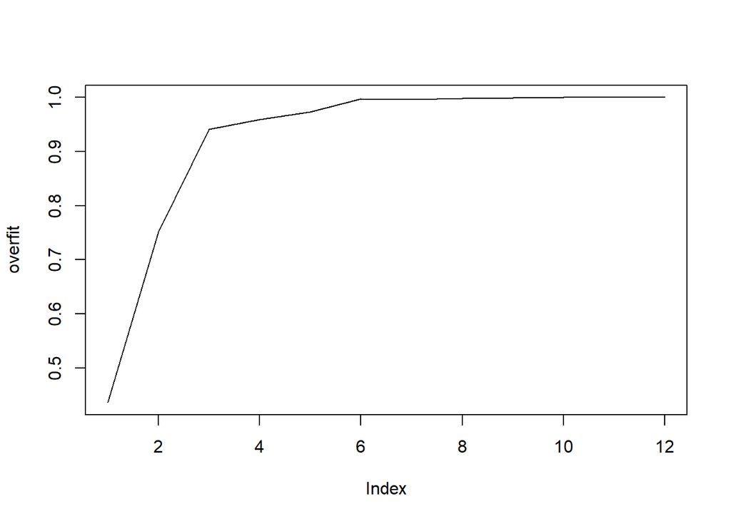

```r
plot(overfit, type = "l")
```

## 3.3: Linear Discriminant Analysis (LDA)

The Linear Discriminant Analysis is a pattern recognition, and machine learning model that finds a linear combination of featurs that characterizes or seperates two or more classes of events.

```r
lda_USA <- lda(Direction~ LBR.IUSA + YPQ.IUSA + GDPQ.IUSA + XHOFHOPIQ.IUSA,data=CIDtrain)
lda_USA
```

```
## Call:
## lda(Direction ~ LBR.IUSA + YPQ.IUSA + GDPQ.IUSA + XHOFHOPIQ.IUSA,
##     data = CIDtrain)
##
## Prior probabilities of groups:
##      Down        Up
## 0.6382979 0.3617021
##
## Group means:
##      LBR.IUSA YPQ.IUSA GDPQ.IUSA XHOFHOPIQ.IUSA
## Down 6.892333 13909217  16358573       335.6447
## Up   6.270588 12327271  14722076       357.6600
##
## Coefficients of linear discriminants:
##                          LD1
## LBR.IUSA        6.676402e-01
## YPQ.IUSA        3.212931e-06
## GDPQ.IUSA      -3.516294e-06
## XHOFHOPIQ.IUSA  8.681290e-02
```

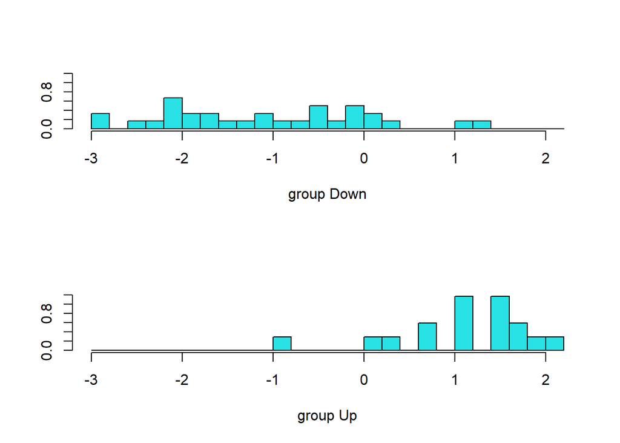

```r
plot(lda_USA)
```

One downside to LDA is the assumption that the measurements from each class are normally distributed. In the lda plot, note that the each groups distribution is not normally distributed. This will casuse issues in fitting the model.

```r
ldaPred <- predict(lda_USA,CIDtest)
ldaPred$class
```

```
##  [1] Down Up   Up   Up   Up   Up   Up   Up   Up   Up   Up   Up
## Levels: Down Up
```

```r
table(ldaPred$class,CIDtest$Direction)
```

```
##
##        Down Up
##   Down    0  1
##   Up      9  2
```

```r
mean(ldaPred$class==CIDtest$Direction)
```

```
## [1] 0.1666667
```

**Model Summary**

This model has a 16% accuracy. It misclasses nealry all of the predictions due to the underlying assumption that each group should be normally distributed.

## 3.4: Quadratic Discriminant Analysis (QDA)

In the Quadratic Discriminant Analysis it is closely related to linear discriminant analysis, where it is assumed that the measurements from each class are normally distributed. However, in QDA there are no assumptions about the covariane of each of the classes.

```r
qda_USA <- qda(Direction~ LBR.IUSA + YPQ.IUSA + GDPQ.IUSA + XHOFHOPIQ.IUSA,data=CIDtrain)
qda_USA
```

```
## Call:
## qda(Direction ~ LBR.IUSA + YPQ.IUSA + GDPQ.IUSA + XHOFHOPIQ.IUSA,
##     data = CIDtrain)
##
## Prior probabilities of groups:
##      Down        Up
## 0.6382979 0.3617021
##
## Group means:
##      LBR.IUSA YPQ.IUSA GDPQ.IUSA XHOFHOPIQ.IUSA
## Down 6.892333 13909217  16358573       335.6447
## Up   6.270588 12327271  14722076       357.6600
```

```r
qdaPred <- predict(qda_USA,CIDtest)
qdaPred$class
```

```
##  [1] Down Down Down Down Down Down Down Down Down Down Down Down
## Levels: Down Up
```

```r
table(qdaPred$class,CIDtest$Direction)
```

```
##
##        Down Up
##   Down    9  3
##   Up      0  0
```

```r
mean(qdaPred$class==CIDtest$Direction)
```

```
## [1] 0.75
```

**Model Summary**

With no underlying assumptions the QDA model shows a better fit compared to the LDA. The QDA model has a 75% accuracy. Comparing this to the other classification models used (LRC and LDA) it is the 2nd best model. Overall, this model is useful when predicting the direction delinquency rates will move over time but it will not forecasting the magnitude of that move.

# 4: Non-Parametric Model

Non-parametric methods seek to find the best fit for the training data while maintaining some ability to generalize unseen data.

**Benefits of Non-parametric Machine learning Algorithms:**

- Capable of fitting a large number of functional forms
- No assumptions about the underlying function
- Performance

**Limitations of Non-parametric Machine learning Algorithms:**

- Requires more data
- More of a risk to overfit the training data

## 4.1: Decision Tree

In this section, a Decision Tree is used to fit the model. A decision tree is a decision support tool that uses a tree-like model of decision and their possible consequences, i.e. change event outcomes.

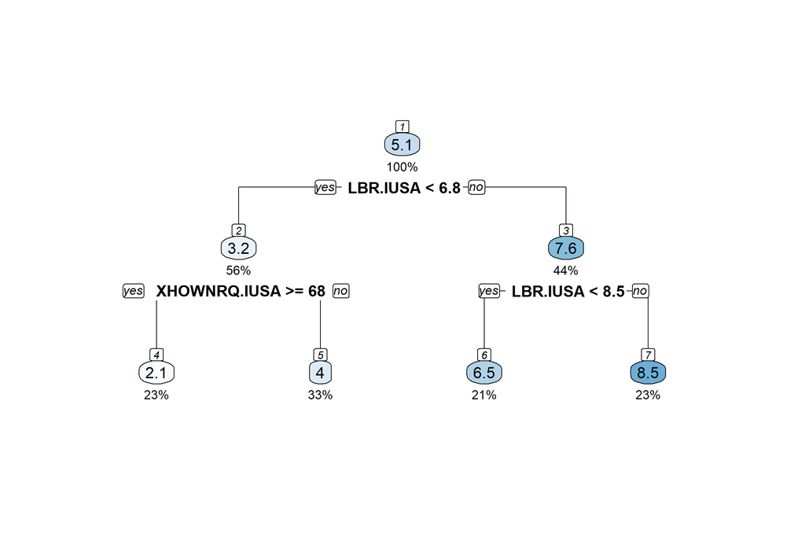

```r
#Tree ----
USA.tree <- rpart(XMBASDR.IUSA ~ LBR.IUSA + YPQ.IUSA + GDPQ.IUSA + XHOWNRQ.IUSA + XHOFHOPIQ.IUSA, data = USA.train)
rpart.plot(USA.tree, yesno = 2, under = TRUE, tweak = 1.4, nn= TRUE)
```

```r
#MSE
yhat <- predict(USA.tree, newdata = USA.test)
mean((yhat - USA.test$XMBASDR.IUSA)^2)
```

```
## [1] 2.943657
```

**Model Summary**

The Decision Tree is made up of 7 nodes represented with the blue circles. Below the node the nubmer shows the percetage of data that the node represents.

The Root, node 1, splits the data by unemployment. The root node branches off into 2 child nodes, node 2 and node 3. The root node determines if unemployment is less than 6.8% and breaks up the data accordingly.

If umeployment is over 6.8% move to node 3. Then ask if unemployment is less than 8.5%. If unemployment is less than 8.5% the delinquency rate will be 6.5% (node 6), else delinquency rate will be 8.5% (node 7).

## 4.2: Quantile Regression

While traditional linear regression models use the conditional mean of the dependent variable, quantile regression models use the conditional median or other quantiles. Quantile regression makes no assumptions about the distribution of the underlying data.

This models uses the mdeian of the dependent variable, which is indicated with the tau = 0.5 option.

```r
q <- rq(XMBASDR.IUSA ~ LBR.IUSA + YPQ.IUSA + GDPQ.IUSA + XHOFHOPIQ.IUSA, data = USA.train, tau = 0.5)
summary(q$residuals)
```

```
##     Min.  1st Qu.   Median     Mean  3rd Qu.     Max.
## -0.74663 -0.18091  0.00000  0.09716  0.25223  1.25964
```

```r
q$coefficients
```

```
##    (Intercept)       LBR.IUSA       YPQ.IUSA      GDPQ.IUSA XHOFHOPIQ.IUSA
##  -1.219304e+01   1.493183e+00   6.072646e-07  -3.578832e-07   1.422005e-02
```

```r
qPred <- predict(q,USA.test)
qPred
```

```
##       48       49       50       51       52       53       54       55
## 3.488821 3.329770 3.193122 3.199222 3.072615 3.173094 3.082882 2.968291
##       56       57       58       59       60
## 3.092667 3.358485 3.150132 3.228231 3.151150
```

```r
mean((qPred - USA.test$XMBASDR.IUSA)^2)
```

```
## [1] 0.8828787
```

**Model Summary**

The residuals of the model are not quite normally distributed which would be bad for a linear regression, but in a quantile regress there are no assumptions. The equation will be similar to the linear regression with respect to the coefficients. The key takeaway from this model is that it shows the lowest MSE tested yet. This indicates a low error with the predicted values vs the real test data.

## 4.3: Local Regression

The idea is to fit a curve to data by averaging, or otherwise summarizing, data points that are next to one another. The amount of “wiggliness” of the curve can be adjusted.

Local regression is useful for investigating the behavior of the response variable in more detail than would be possible with a simple linear model.

```r
LocalReg <- loess(XMBASDR.IUSA ~ LBR.IUSA + YPQ.IUSA + GDPQ.IUSA + XHOFHOPIQ.IUSA,
                  data = USA.train,
                  span = 0.85,
                  control = loess.control(surface = "direct"),
                  family = "gaussian")

LocalPred <- predict(LocalReg, USA.test, se = TRUE)
LocalPred$fit
```

```
##       48       49       50       51       52       53       54       55
## 3.004133 2.442449 2.339042 2.762519 2.646195 1.478155 3.399193 4.092465
##       56       57       58       59       60
## 3.706556 1.930426 2.922484 4.366333 5.475143
```

```r
mean((LocalPred$fit - USA.test$XMBASDR.IUSA)^2)
```

```
## [1] 2.354101
```

```r
LocalReg2 <- loess(XMBASDR.IUSA ~ LBR.IUSA + YPQ.IUSA + GDPQ.IUSA + XHOFHOPIQ.IUSA,
                  data = USA.train,
                  span = 0.95,
                  control = loess.control(surface = "direct"),
                  family = "gaussian")

LocalPred2 <- predict(LocalReg2, USA.test, se = TRUE)
LocalPred2$fit
```

```
##       48       49       50       51       52       53       54       55
## 2.977314 2.334871 2.257349 2.570022 2.381559 1.287570 2.847702 3.362846
##       56       57       58       59       60
## 3.034179 1.739787 2.627515 3.799593 4.638550
```

```r
mean((LocalPred2$fit - USA.test$XMBASDR.IUSA)^2)
```

```
## [1] 1.369978
```

**Model Summary**

The key takeaway of this model is as $\alpha$, which controls the degree of smoothing, increase so does the model fit. This indicates that the data does not exactly follow a linear line it may have a longer tail on one side.

## 4.4: K-Nearest Neighbor (K-NN) Classification

K-NN is an approach to data classification that estimates how likely a data point is to be a memeber of one group or the other depending on what group the data points nearest to.

```r
knn_test <- CIDtest[,c(2,3,4,6)]
knn_train <- CIDtrain[,c(2,3,4,6)]

knn_pred <- knn(knn_train, knn_test, CIDtrain$Direction, k=1)
table(CIDtest$Direction, knn_pred)
```

```
##       knn_pred
##        Down Up
##   Down    0  9
##   Up      0  3
```

```r
mean(knn_pred == CIDtest$Direction)
```

```
## [1] 0.25
```

```r
knn_pred2 <- knn(knn_train, knn_test, CIDtrain$Direction, k=2)
table(CIDtest$Direction, knn_pred2)
```

```
##       knn_pred2
##        Down Up
##   Down    1  8
##   Up      1  2
```

```r
mean(knn_pred2 == CIDtest$Direction)
```

```
## [1] 0.25
```

```r
knn_pred3 <- knn(knn_train, knn_test, CIDtrain$Direction, k=3)
table(CIDtest$Direction, knn_pred3)
```

```
##       knn_pred3
##        Down Up
##   Down    9  0
##   Up      3  0
```

```r
mean(knn_pred3 == CIDtest$Direction)
```

```
## [1] 0.75
```

**Model Summary**

For K-NN there are 3 different models with verying fits. For model 1 it uses 1 neighbour in its analysis and each model increases the neighbours considered i.e model 3 considers 3. Increasing neighbours after using more than 3 neighbours resulted in the same predictions. The best fit obtained for this model was 75% accuracy.

# 5: Results

Mean Squared Error (MSE) is the average of all of the squared differences between the true values and the predicted values. Below, are the MSE for each model tested. When considering model accuracy, the lower MSE value, the greater the model’s accuracy.

| Model | MSE |
| --- | --- |
| Linear Model (All) | 5.2071313 |
| Linear Model (Sig) | 0.9511543 |
| Decision Tree | 2.9436573 |
| Quantile Regression | 0.8828787 |
| Local Regression | 1.3699775 |

**Quantile Regression** has the lowest MSE for the Non-Parametric Model and overall. **Linear Model (Sig)** has the lowest MSE of all Parametric Models tested.

The next table shows the true test data and each models’ predicted values for 13 quarters (3+ years).

```r
results <- rbind(USA.test$XMBASDR.IUSA,pred_USA,pred_USA2,yhat,qPred,LocalPred2$fit)
results <- round(results,digits =2)
rownames(results) <- c("Test Data", "Linear Model (ALL) Prediction", "Linear Model (Sig) Prediction*", "Tree Prediction", "Quantile Prediction*", "Local Prediction" )
kable(results)
```

|  | 48 | 49 | 50 | 51 | 52 | 53 | 54 | 55 | 56 | 57 | 58 | 59 | 60 |
| --- | --- | --- | --- | --- | --- | --- | --- | --- | --- | --- | --- | --- | --- |
| Test Data | 3.13 | 2.76 | 2.49 | 2.52 | 2.91 | 2.61 | 2.30 | 2.13 | 2.06 | 1.96 | 1.95 | 1.81 | 1.76 |
| Linear Model (ALL) Prediction | 3.70 | 3.65 | 3.63 | 3.82 | 4.05 | 4.34 | 4.36 | 4.40 | 4.85 | 4.91 | 4.73 | 5.28 | 5.45 |
| Linear Model (Sig) Prediction* | 3.50 | 3.41 | 3.29 | 3.24 | 3.12 | 3.30 | 3.09 | 2.96 | 3.10 | 3.43 | 3.22 | 3.24 | 3.13 |
| Tree Prediction | 4.00 | 4.00 | 4.00 | 4.00 | 4.00 | 4.00 | 4.00 | 4.00 | 4.00 | 4.00 | 4.00 | 4.00 | 4.00 |
| Quantile Prediction* | 3.49 | 3.33 | 3.19 | 3.20 | 3.07 | 3.17 | 3.08 | 2.97 | 3.09 | 3.36 | 3.15 | 3.23 | 3.15 |
| Local Prediction | 2.98 | 2.33 | 2.26 | 2.57 | 2.38 | 1.29 | 2.85 | 3.36 | 3.03 | 1.74 | 2.63 | 3.80 | 4.64 |

## 5.1: Best Parametric Model

In the previous section it was determined that Linear Model (Sig) was the best Parametric Model to forecast Delinquency Rates.

**Formula**

The multiple linear regression equation is as follows:

$\hat{Y} = \beta_{0} + \beta_{1}X_{1} + \beta_{2}X_{2} +...+ \beta_{p}X_{p}$,

Where $\hat{Y}$ is the expected value of the response variable, $X_{1}$ to $X_{p}$ are the predictor variables, and $b_{0}$ to $\beta_{p}$ are the estimated regression coefficients.

```r
Model3 <- summary(fit_USA2)
Model3$coefficients
```

```
##                     Estimate   Std. Error   t value     Pr(>|t|)
## (Intercept)    -1.020987e+01 2.313768e+00 -4.412660 6.744756e-05
## LBR.IUSA        1.442499e+00 6.398797e-02 22.543276 1.909595e-25
## YPQ.IUSA        1.487088e-06 5.215252e-07  2.851421 6.661530e-03
## GDPQ.IUSA      -1.269484e-06 5.048958e-07 -2.514348 1.574733e-02
## XHOFHOPIQ.IUSA  1.738615e-02 5.118456e-03  3.396756 1.478545e-03
```

Linear Model (sig)’s formula is as follows:

$DelinquencyRate = -10.21 + (1.44*UR) + (1.48e^{-6}*PI) -(1.27e^{-6}*GDP) + (1.74e^{-2}*HomePrice)$,

where UR is unemployment rate and PI is personal Income.

**Forecasting**

Linear Model (sig) is broken out into 4, 8, 12, and 13 Quarter time frames. Forecasting out 8 quarters yields similar Mean Squared Error (MSE). Forecasting 12-13 quarters out gets more problematic as the MSE nearly doubles.

**With an 84.14% accuracy rate when forecasting 4 quarters ahead, Linear Model (sig) has proven to be the most suitable option for predicting delinquency rates with a Parametric Model.**

```r
#1 Year
OneYear <- mean((pred_USA2[1:4] - USA.test$XMBASDR.IUSA[1:4])^2)
#accuracy
OneYearA <- (1- (mean((pred_USA2[1:4] - USA.test$XMBASDR.IUSA[1:4])^2)/ mean(USA.test$XMBASDR.IUSA[1:4])))*100

#2 Years
TwoYear <- mean((pred_USA2[1:8] - USA.test$XMBASDR.IUSA[1:8])^2)
#accuracy
TwoYearA <- (1- (mean((pred_USA2[1:8] - USA.test$XMBASDR.IUSA[1:8])^2)/ mean(USA.test$XMBASDR.IUSA[1:8])))*100

#3 Years
ThreeYear <- mean((pred_USA2[1:12] - USA.test$XMBASDR.IUSA[1:12])^2)
#accuracy
ThreeYearA <- (1- (mean((pred_USA2[1:12] - USA.test$XMBASDR.IUSA[1:12])^2)/ mean(USA.test$XMBASDR.IUSA[1:12])))*100

#Full Forecast
Full <- mean((pred_USA2 - USA.test$XMBASDR.IUSA)^2)
#accuracy
FullA <- (1- (mean((pred_USA2 - USA.test$XMBASDR.IUSA)^2)/ mean(USA.test$XMBASDR.IUSA)))*100

Model3Results <- rbind(OneYear,TwoYear,ThreeYear,Full)
Model3A <- rbind(OneYearA,TwoYearA,ThreeYearA,FullA)
Model3Results <- cbind(Model3Results, Model3A)

rownames(Model3Results) <- c("One Year Forecast (4Q)","Two Year Forecast (8Q)","Three Year Forecast (12Q)","Full Forecast (13Q)")
colnames(Model3Results) <-c("MSE", "Model Accuracy (%)")
kable(Model3Results)
```

|  | MSE | Model Accuracy (%) |
| --- | --- | --- |
| One Year Forecast (4Q) | 0.4322459 | 84.13777 |
| Two Year Forecast (8Q) | 0.4469878 | 82.84939 |
| Three Year Forecast (12Q) | 0.8732690 | 63.39774 |
| Full Forecast (13Q) | 0.9511543 | 59.31226 |

## 5.2: Best Non-Parametric Model

At the start of section 5, Quantile Regression was identified as the top preforming model overall.

The quantile regression takes a similar structure to the linear regression model, the formula for the $\tau$th quantile is

$Q_{\tau}(y_{i}) = \beta_{0}(\tau)x_{i1} +...+ \beta_{p}(\tau)x_{ip}$,

This means that instead of being constant, the $\beta$ coefficients are now functions with a dependency on the quantile.

```r
q$coefficients
```

```
##    (Intercept)       LBR.IUSA       YPQ.IUSA      GDPQ.IUSA XHOFHOPIQ.IUSA
##  -1.219304e+01   1.493183e+00   6.072646e-07  -3.578832e-07   1.422005e-02
```

where UR is unemployment rate and PI is personal Income.

**Forecasting**

Quantile Regression is broken out into 4, 8, 12, and 13 Quarter time frames.

The forecasting has a very similar sturcture to the linear regression. There is the same signifiant drop in accuracy when forecasting out 3 years.

**With an 87.07% accuracy rate when forecasting 4 quarters ahead, the Median Quantile Regression has proven to be the most suitable option for predicting delinquency rates.**

```r
#1 Year
OneYearQ <- mean((qPred[1:4] - USA.test$XMBASDR.IUSA[1:4])^2)
#accuracy
OneYearQA <- (1- (mean((qPred[1:4] - USA.test$XMBASDR.IUSA[1:4])^2)/ mean(USA.test$XMBASDR.IUSA[1:4])))*100

#2 Years
TwoYearQ <- mean((qPred[1:8] - USA.test$XMBASDR.IUSA[1:8])^2)
#accuracy
TwoYearQA <- (1- (mean((qPred[1:8] - USA.test$XMBASDR.IUSA[1:8])^2)/ mean(USA.test$XMBASDR.IUSA[1:8])))*100

#3 Years
ThreeYearQ <- mean((qPred[1:12] - USA.test$XMBASDR.IUSA[1:12])^2)
#accuracy
ThreeYearQA <- (1- (mean((qPred[1:12] - USA.test$XMBASDR.IUSA[1:12])^2)/ mean(USA.test$XMBASDR.IUSA[1:12])))*100

#Full Forecast
FullQ <- mean((qPred - USA.test$XMBASDR.IUSA)^2)
#accuracy
FullQA <- (1- (mean((qPred - USA.test$XMBASDR.IUSA)^2)/ mean(USA.test$XMBASDR.IUSA)))*100

ModelQResults <- rbind(OneYearQ,TwoYearQ,ThreeYearQ,FullQ)
ModelQA <- rbind(OneYearQA,TwoYearQA,ThreeYearQA,FullQA)
ModelQResults <- cbind(ModelQResults, ModelQA)

rownames(ModelQResults) <- c("One Year Forecast (4Q)","Two Year Forecast (8Q)","Three Year Forecast (12Q)","Full Forecast (13Q)")
colnames(ModelQResults) <-c("MSE", "Model Accuracy (%)")
kable(ModelQResults)
```

|  | MSE | Model Accuracy (%) |
| --- | --- | --- |
| One Year Forecast (4Q) | 0.3522783 | 87.07236 |
| Two Year Forecast (8Q) | 0.3835335 | 85.28409 |
| Three Year Forecast (12Q) | 0.7951770 | 66.67089 |
| Full Forecast (13Q) | 0.8828787 | 62.23290 |